# Geographical Mapping: Parking Violations in NYC

YI YIN

2019-02-24

# Scope

- Data exploration
- Choropleth maps
- Use geo-coding API to locate address for mapping
- Interactive map with hover-over information
- Interactive map with clustering

# Data exploration

## a) Violation Code and Fine Amounts

Provide a visual overview of the top 10 most common types of violations

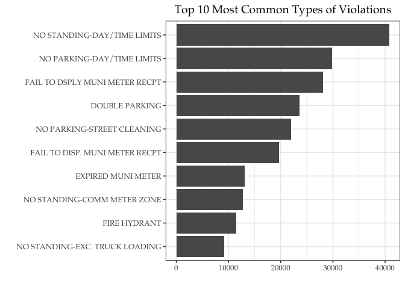

Compare how this ranking differs if we focus on the total amount of revenue generated.

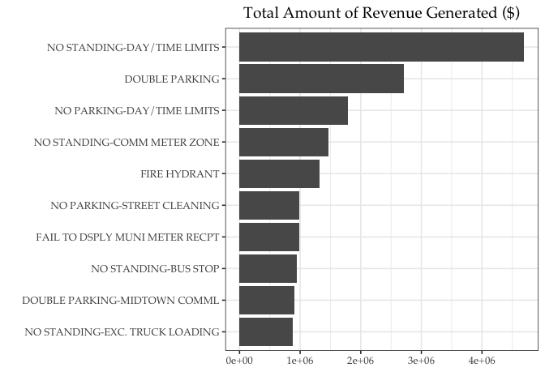

## b) Average amount of fine by vehicle

Compare the average amount of fine by vehicle color, vehicle year, and vehicle plate type.

```
## # A tibble: 2 x 2
##   plate_type   avg
##   <chr>      <dbl>
## 1 COM         79.8
## 2 PAS         78.6
```

```
## # A tibble: 117 x 2
##    vehicle_color   avg
##    <chr>         <dbl>
##  1 B               115
##  2 BRN             115
##  3 BRO             115
##  4 BRWN            115
##  5 BWN             115
##  6 DKM             115
##  7 FR              115
##  8 GLD             115
##  9 GRA             115
## 10 GREE            115
## # … with 107 more rows
```

```
## # A tibble: 50 x 2
##    vehicle_year   avg
##           <dbl> <dbl>
##  1         1993  95.4
##  2         1990  94.8
##  3         1988  92.5
##  4         1997  92.0
##  5         1986  90.0
##  6         1983  90
##  7         2020  89
##  8         1992  86.9
##  9         1987  86.7
## 10         1995  86.5
## # … with 40 more rows
```

# Choropleth maps

Map by Precincts: Read in the shape files for the police precincts and remove all precincts outside of Manhattan.

## a) Number of tickets, total fines, and average fines

Provide three maps that show choropleth maps of:

### The Total Number of Tickets

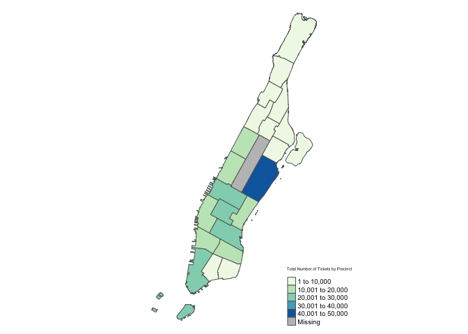

### The Total Amount of Fines

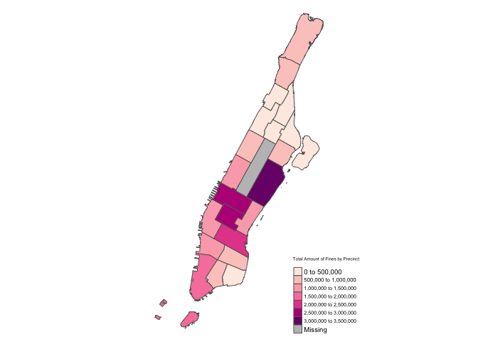

### The Average Amount of Fines

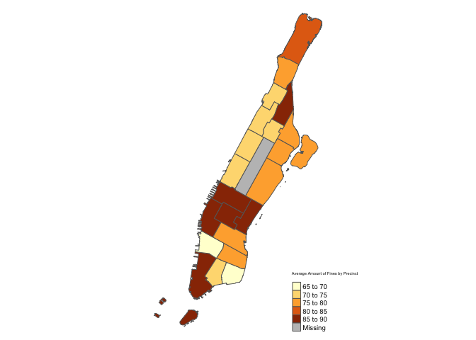

Upper east side has the highest total number of tickets, and total amount of fines. While Midtown has the highest average amount of fines.

## b) Types of violations

Group the almost 100 types of ticket violations into a smaller set of 4-6 subgroups.

A Choropleth maps for each of these subgroups to show where different types of violations are more or less common.

Four main groups:

- NO STAND
- NO PARKING
- MISSING
- FAIL TO

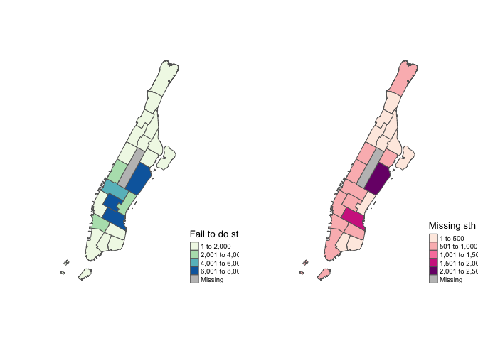

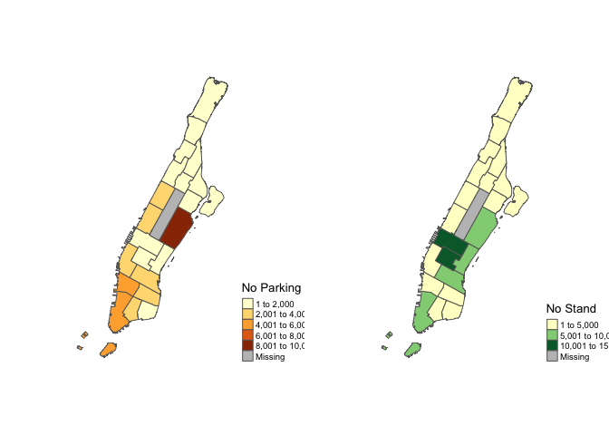

# 3. Use geo-coding API to locate address for mapping

## a) Geocode at least 500 addresses of violations

500 Violations on Ignoring Fire Hydrants

Include a data table of these addresses and the latitude and longitude of these addresses in the output.

```
## # A tibble: 500 x 3
##    address                           lat   lon
##    <chr>                           <dbl> <dbl>
##  1 E 95th St 301 New York, NY       40.8 -73.9
##  2 E 93rd St 118 New York, NY       40.8 -74.0
##  3 E 69th St 201 New York, NY       40.8 -74.0
##  4 Madison Ave 744 New York, NY     40.8 -74.0
##  5 E 70th St 331 New York, NY       40.8 -74.0
##  6 Lexington Ave 1291 New York, NY  40.8 -74.0
##  7 E 75th St N New York, NY         40.8 -74.0
##  8 E 73rd St 328 New York, NY       40.8 -74.0
##  9 E 78th St 205 New York, NY       40.8 -74.0
## 10 E 92nd St N New York, NY         40.8 -74.0
## # … with 490 more rows
```

# Interactive map with hover-over information

Provide an interactive map of the violations you geocoded using leaflet. Provide at least three pieces of information on the parking ticket in a popup.

[interactive chart not shown]

## c) Luxury Cars and Repeat Offenders

Using the vehicle Plate ID, identify repeat offenders (in the full data set).

Start with the previous map. Distinguish the points by whether the car is a repeat offender and/or luxury car. Add a legend informing the user about the color scheme.

Also make sure that the added information about the car type and repeat offender status is now contained in the pop-up information.

[interactive chart not shown]

# Interactive map with clustering

[interactive chart not shown]